# Excercise 3 - Logistic regression

## Introduction and data

We are exploring data from two questionnaires focusing on high school student performance and alcohol consumption from two portuguese schools.

We import the data into R from a local data file. Source data can be found here: https://archive.ics.uci.edu/ml/datasets/Student+Performance

```r
alc <- read.table("data/alc.txt")
colnames(alc)
```

```
##  [1] "school"     "sex"        "age"        "address"    "famsize"
##  [6] "Pstatus"    "Medu"       "Fedu"       "Mjob"       "Fjob"
## [11] "reason"     "nursery"    "internet"   "guardian"   "traveltime"
## [16] "studytime"  "failures"   "schoolsup"  "famsup"     "paid"
## [21] "activities" "higher"     "romantic"   "famrel"     "freetime"
## [26] "goout"      "Dalc"       "Walc"       "health"     "absences"
## [31] "G1"         "G2"         "G3"         "alc_use"    "high_use"
```

There are variables in the data are listed above. There is binary, nominal and numeric data relating to background and behavior of students. G1-G3 are grades, (g3 is the final grade). “alc_use” is constructed as the mean of “Dalc” and “Walc”, “high_use” is a binary TRUE or FALSE for high alcohol use (TRUE when alc_use >2). More detailed information can be found behind the link above.

## We are going to study the relationships between high/low alcohol consumption and these 4 arbitrarily choosen variables:

- Medu - Mothers level of education (numeric 0-4). 0 is none, 4 is higher education. Hypothesis: Lower alcohol consumption with higher mothers education level.
- abscences - number of school abscences (numeric 0 to 45) Hypothesis: many abscences related to higher alcohol consumption.
- schoolsup - extra educational support (binary yes or no) Hypothesis: need of school support related to higher alcohol consumption.
- failures - number of previous class failure (numeric: range 0-3): Hypothesis: previous failures relates to hihger alcohol consumption.

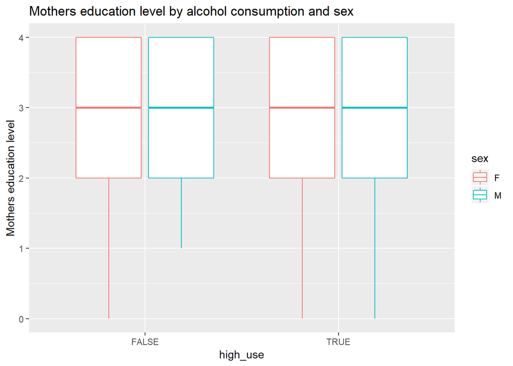

```r
# initialize a plot of high_use and Medu
Meduplot <- ggplot(alc, aes(x = high_use, y = Medu, col = sex))

# define the plot as a boxplot and draw it
Meduplot + geom_boxplot() + ylab("Mothers education level") +ggtitle("Mothers education level by alcohol consumption and sex")
```

No visible difference between students mothers education levels when grouped by high_use.

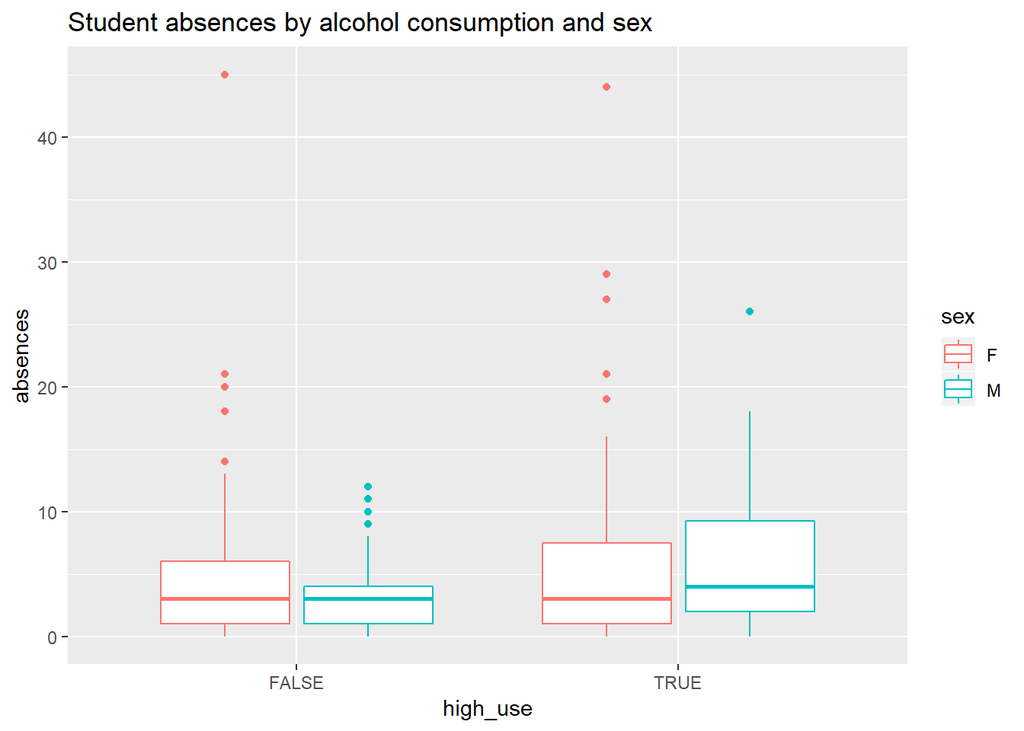

```r
# initialise a plot of high_use and absences
absencesplot <- ggplot(alc, aes(x = high_use, y = absences, col = sex))

# define the plot as a boxplot and draw it
absencesplot +geom_boxplot() + ggtitle("Student absences by alcohol consumption and sex")
```

A tendence towards more abscences with higher alcohol consumption.

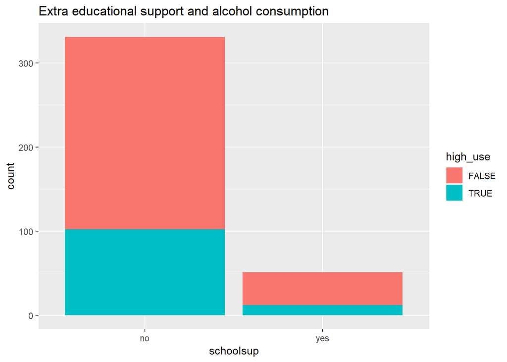

```r
#barplot with number of students
ggplot(data=alc, aes(x=schoolsup, fill=high_use)) + geom_bar() + ggtitle("Extra educational support and alcohol consumption")
```

Proportion of students with high alcohol use seems to be less in the group receiving Extra school support

```r
# Cross-tabulate by failures and high_use
alc %>% group_by(failures, high_use) %>% summarise(count = n())
```

```
## # A tibble: 8 x 3
## # Groups:   failures [?]
##   failures high_use count
##      <int> <lgl>    <int>
## 1        0 FALSE      244
## 2        0 TRUE        90
## 3        1 FALSE       12
## 4        1 TRUE        12
## 5        2 FALSE       10
## 6        2 TRUE         9
## 7        3 FALSE        2
## 8        3 TRUE         3
```

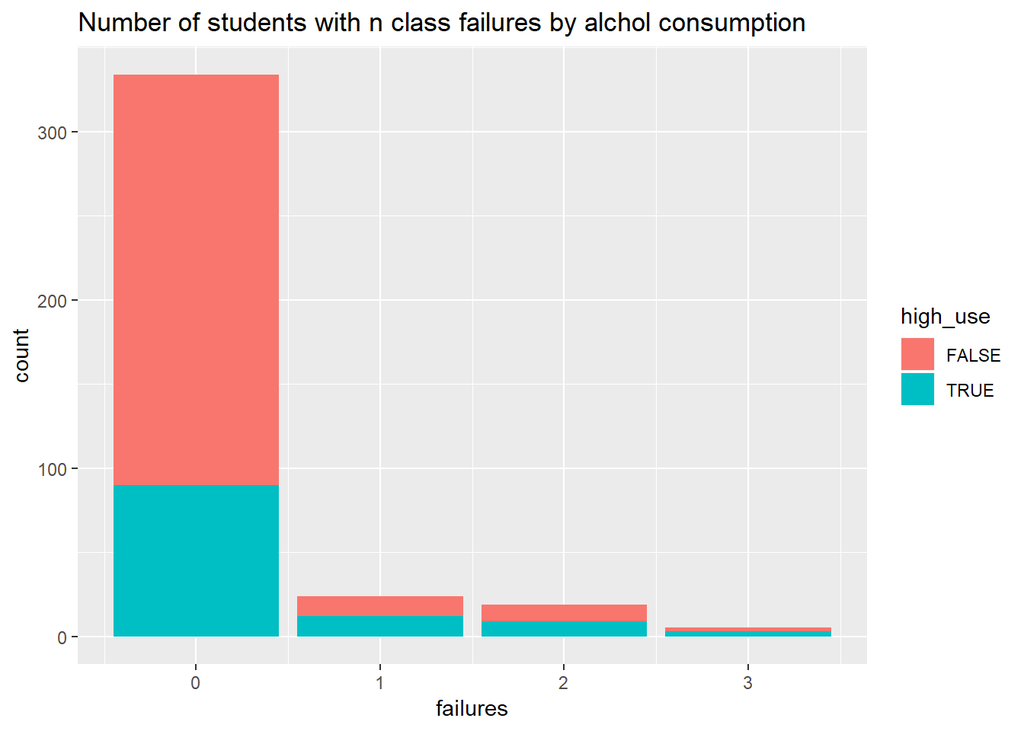

```r
ggplot(data=alc, aes(x=failures, fill=high_use)) + geom_bar() + ggtitle("Number of students with n class failures by alchol consumption")
```

Students with high alcohol consumption are overrepresented in the groups with previous class failures.

## Logistic regression

We use the function glm() to fit a logistic regression model “m” with *high_use* as target, and *Medu*, *abscences*, *schoolsup* and *failures* as predictors and print a summary.

```r
m <- glm(high_use ~ Medu + absences + schoolsup + failures, data = alc, family = "binomial")
summary(m)
```

```
##
## Call:
## glm(formula = high_use ~ Medu + absences + schoolsup + failures,
##     family = "binomial", data = alc)
##
## Deviance Residuals:
##     Min       1Q   Median       3Q      Max
## -2.2871  -0.8081  -0.7056   1.2096   1.9285
##
## Coefficients:
##              Estimate Std. Error z value Pr(>|z|)
## (Intercept)  -1.49792    0.36611  -4.092 4.29e-05 ***
## Medu          0.05863    0.11326   0.518 0.604693
## absences      0.08581    0.02305   3.723 0.000197 ***
## schoolsupyes -0.42697    0.36812  -1.160 0.246102
## failures      0.53531    0.19401   2.759 0.005794 **
## ---
## Signif. codes:  0 '***' 0.001 '**' 0.01 '*' 0.05 '.' 0.1 ' ' 1
##
## (Dispersion parameter for binomial family taken to be 1)
##
##     Null deviance: 465.68  on 381  degrees of freedom
## Residual deviance: 438.37  on 377  degrees of freedom
## AIC: 448.37
##
## Number of Fisher Scoring iterations: 4
```

Abscences and failures are statistically positively associated with high use of alcohol. (p <0.05)

Next we compute odds ratios with confidence intervals from the coefficients of the model with the exp function.

```r
# compute odds ratios
OR <- coef(m) %>% exp

# compute confidence intervals (CI)
CI <- confint(m) %>% exp
# print out the odds ratios with their confidence intervals
cbind(OR, CI)
```

```
##                     OR     2.5 %    97.5 %
## (Intercept)  0.2235938 0.1067127 0.4499919
## Medu         1.0603825 0.8505919 1.3273428
## absences     1.0896003 1.0437001 1.1424496
## schoolsupyes 0.6524844 0.3050016 1.3052315
## failures     1.7079772 1.1703297 2.5182154
```

The confidence intervals for Medu and schoolsup include the number 1 in the 95% confidence interval range, and thus the association with these and alcohol use is not statistically significant, just as we found in the summary of our model previously. OR 1.089 for abscences means that for each additional abscence the odds for high use of alcohol is 8.9% higher. The same goes for class failures, but the odds are even higher OR = 1.708.

## Predictions of the model vs. actual values

Well rebuild the model using the statistically significant predictors failures and abscences, calculate probabilities for each individual and compare them to actual values.

```r
# fit the model
m2 <- glm(high_use ~ failures + absences, data = alc, family = "binomial")

#  predict() the probability of high_use and add the predicted probabilities to 'alc'
alc <- mutate(alc, probability = predict(m2, type = "response"))

# use the probabilities to make a prediction of high_use( true if prob >0.5)
alc <- mutate(alc, prediction = probability > 0.5)

# tabulate the target variable versus the predictions
table(high_use = alc$high_use, prediction = alc$prediction)
```

```
##         prediction
## high_use FALSE TRUE
##    FALSE   258   10
##    TRUE     99   15
```

This gives us 10 false positives, and 99 false negatives out of 382 observations. That gives a probability of 0.2853403 for false classification. Guessing woud give a probability of 0.5, so this model preforms about twice as good as pure guesswork.